# Optimizing Network Delays with Bandit Algorithms

# Functions

## `simmer_mg1` function: Simulates an M/G/1 queuing system using the simmer package.

Parameters:

- `g`: Graph object representing the network topology.
- `Capacity_Gbps`: Capacity of the links in Gbps.
- `Load`: Load of the system.
- `PS_size`: Packet sizes.
- `PS_weights`: Weights of packet sizes.
- `k_num`: Number of packets to simulate.
- `path_v`: Vector representing the path in the network.

Returns:

- Vector of spending times for the specified number of packets.

```r
simmer_mg1 <- function(g, Capacity_Gbps, Load, PS_size, PS_weights, k_num, path_v){

  # Calculate total number of packets in the system
  N = sum(PS_size * PS_weights)

  # Calculate node capacity in Bps
  nodes_capacity_Bps = Capacity_Gbps * 1e9

  # Get edge IDs for the given path
  path_e <- sapply(2:length(path_v), function(i) {
    get.edge.ids(g, as.vector(c(path_v[i-1], path_v[i])))
  })

  # Calculate capacity per packet in Bps
  Capacity_ps = Capacity_Gbps * 1e9 / (8 * N)

  # Calculate traffic per packet in Bps
  traffic_ps = Capacity_ps * Load

  # Calculate service rate
  mu = 1 / Capacity_ps

  # Calculate variance of the number of packets in the system
  var_N <- sum(PS_size^2 * PS_weights) - N^2
  Cs2 <- var_N / (N^2)

  # Calculate theoretical queue delay for each link in the path
  theor_qeueu_delay_link_mg1 <- mu * Load / (1 - Load) * (1 + Cs2) / 2 + mu
  theor_qeueu_delay_mg1 <- theor_qeueu_delay_link_mg1*length(path_e)
  # Calculate theoretical propagation delay for each link in the path
  theor_prop_delay_link_mg1 <- 5e-6 * E(g)$Distance[path_e]

  # Print total average delay
  cat("Total theoretical average delay", theor_qeueu_delay_mg1 + sum(theor_prop_delay_link_mg1), "s \n")

  # Initialize simulation environment
  env <- simmer()

  # Add resources for each node in the graph
  for (i in 1:length(V(g))) {
    env %>% add_resource(paste0("node_", i), 1)
  }

  # Create trajectory for each link in the path
  trajectory_name <- lapply(1:length(path_e), function(i) {
    trajectory() %>%
      seize(paste0("node_", path_v[i])) %>%
      timeout(function() 8 * sample(PS_size, size = 1, replace = TRUE, prob = PS_weights) / nodes_capacity_Bps) %>%
      release(paste0("node_", path_v[i])) %>%
      timeout(function() theor_prop_delay_link_mg1[i])
  }) %>% join()

  # Define arrival process
  env %>% add_generator("trajectory_name", trajectory_name, function() rexp(1, traffic_ps))

  # Run simulation
  env %>% run(until = (k_num+1e3) / traffic_ps)

  # Get spending times for all arrivals up to k_num
  all_arrivals_res <- data.frame(env %>%
                                   get_mon_arrivals(per_resource = FALSE) %>%
                                   transform(waiting_time_in_queue = round(end_time - start_time - activity_time)) %>%
                                   transform(spending_time = end_time - start_time))

  # Return spending times for k_num arrivals
  return(all_arrivals_res$spending_time[1:k_num])

}
```

## `get_n_trial_convergence` function: Checks convergence based on average rewards.

The convergence criterion is defined as follows:

$$\text{Err} < \text{threshold}$$

where $\text{Err}$ is calculated as:
$$\text{Err} = \frac{\sum_{i=1}^{n}
|\overline{\text{Reward\_curr}}_i -
\overline{\text{Reward\_prev\_n}}_i|}{|\overline{\text{Reward\_prev\_n}}_i|}$$

Here, $\overline{\text{Reward\_curr}}_{i}$ represents the average rewards for the current trial, and $\overline{\text{Reward\_prev\_n}}_{i}$ represents the mean of the previous $n$ average rewards.

```r
get_n_trial_convergence <- function(all_average_rewards, i_trial, conv_num, convergence_threshold) {

  # Check if the current trial is less than or equal to the convergence window
  if (i_trial < conv_num) {
    return(FALSE)  # Not converged yet
  }

  # Retrieve the average rewards for the current trial
  current_average_rewards <-  ifelse(is.na(all_average_rewards[[i_trial]]), 0, all_average_rewards[[i_trial]])

  # Retrieve the previous n average rewards (convergence window)
  prev_n_average_rewards <- all_average_rewards[(i_trial - conv_num):(i_trial - 1)]

  # Calculate the total sum of the previous n average rewards for each iteration
  total_sum <- colSums(do.call(rbind, lapply(prev_n_average_rewards, function(x) ifelse(is.na(x), 0, x))))

  # Calculate the mean of the previous n average rewards
  prev_n_mean <- total_sum / conv_num

  # Calculate the error of the current average rewards according the previous n mean
  error_perc <- sum(abs(current_average_rewards - prev_n_mean))/(abs(sum(prev_n_mean)))*1e2

  # Check if the error is less than the convergence threshold
  if (error_perc < convergence_threshold) {
    cat("Error =", error_perc, "% \n")
    cat("Converged at trial", i_trial, "\n")  # Print convergence message
    converged = TRUE
    cat("Converged:",converged)
    return(TRUE)  # Converged
  } else {
    return(FALSE)  # Not converged yet
  }
}
```

# Definition of basic parameters

```r
path1_v = c(11, 10, 13, 04)
path2_v = c(11, 09, 03, 01)
path3_v = c(11, 12, 15, 20, 16)
path4_v = c(11, 9, 3, 2, 8, 7)
arms = 4 # 4 paths

n_trials <- 10000 # Number of trials
epsilon <- 0.7 # Exploration rate

PS_size=c((64+127)/2,(128+255)/2,(256+511)/2, (512+1023)/2, (1024+1513)/2, 1514, (1515+9100)/2)
PS_weights=c(33.2/100, 5.4/100, 3.3/100, 3.7/100, 34.6/100, 14.6/100, 5.2/100)
N = sum(PS_size*PS_weights)
N
```

```
## [1] 1019.035
```

```r
topology_name = "Tokyo"
file_name_v2 <- "input_files/Metro_topology_full_Tokyo.xlsx"
nodes_info <- read_excel(file_name_v2, sheet = 1)
links_info <- read_excel(file_name_v2, sheet = 2)
```

# igraph calculations

```
## National nodes: 1 4 5
```

```
## Regional nodes: 7 13 16
```

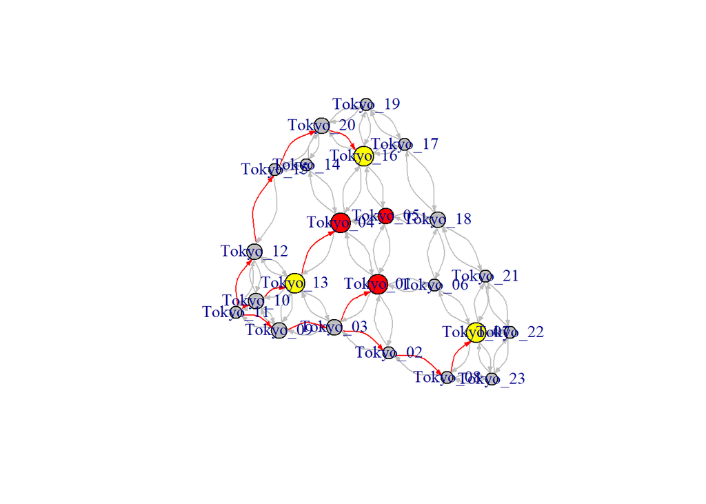

```
## Distance for path1: 2.6 km
```

```
## Distance for path2: 3 km
```

```
## Distance for path3: 2.8 km
```

```
## Distance for path4: 5 km
```

```r
k_num = n_trials
mg1_packets_path1 <- simmer_mg1(g, Capacity_Gbps = 10, Load = 0.8, PS_size, PS_weights, k_num, path1_v)
```

```
## Total theoretical average delay 2.669341e-05 s
```

```r
mg1_packets_path2 <- simmer_mg1(g, Capacity_Gbps = 10, Load = 0.5, PS_size, PS_weights, k_num, path2_v)
```

```
## Total theoretical average delay 2.025762e-05 s
```

```r
mg1_packets_path3 <- simmer_mg1(g, Capacity_Gbps = 10, Load = 0.4, PS_size, PS_weights, k_num, path3_v)
```

```
## Total theoretical average delay 1.976041e-05 s
```

```r
mg1_packets_path4 <- simmer_mg1(g, Capacity_Gbps = 10, Load = 0.1, PS_size, PS_weights, k_num, path4_v)
```

```
## Total theoretical average delay 2.959687e-05 s
```

```r
cat("Total simulated average delay path1", mean(mg1_packets_path1), "s \n")
```

```
## Total simulated average delay path1 2.779951e-05 s
```

```r
cat("Total simulated average delay path2", mean(mg1_packets_path2), "s \n")
```

```
## Total simulated average delay path2 2.030914e-05 s
```

```r
cat("Total simulated average delay path3", mean(mg1_packets_path3), "s \n")
```

```
## Total simulated average delay path3 1.984016e-05 s
```

```r
cat("Total simulated average delay path4", mean(mg1_packets_path4), "s \n")
```

```
## Total simulated average delay path4 2.966001e-05 s
```

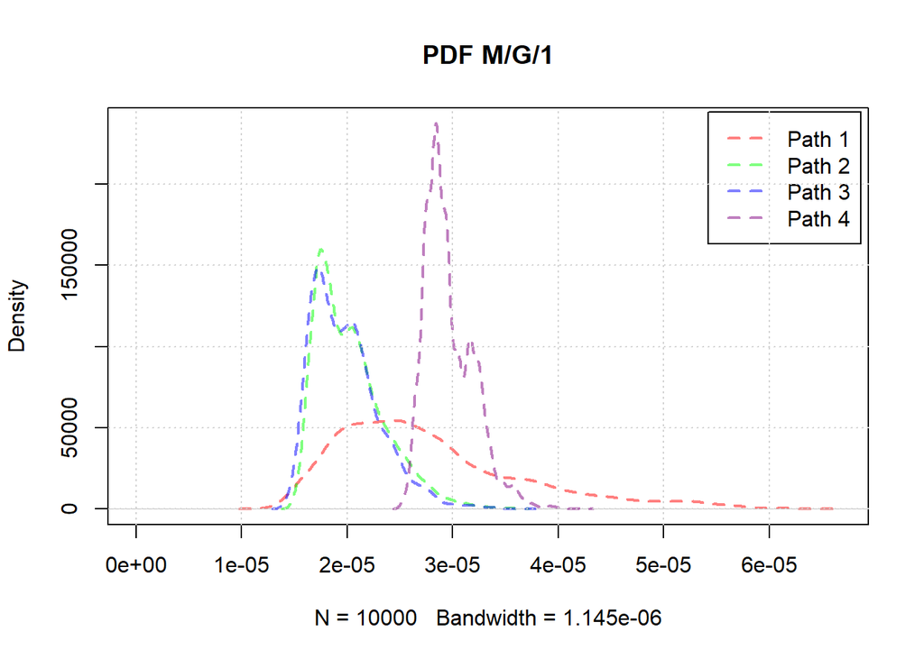

# Simulation for the average delay

## Initialization

```r
#arms <- length(mu)
counts <- numeric(arms) # A vector initialized with zeros to track how many times each path has been selected
rewards <- numeric(arms) # A vector initialized with zeros to accumulate the total rewards (negative delays) obtained from each path
```

- `conv_num`: This variable represents the number of previous trials used for convergence checking. It specifies the number of previous average rewards to consider when checking for convergence.
- `convergence_threshold`: This variable defines the threshold for convergence, maximum allowed variance between the current average rewards and the mean of the previous `conv_num` average rewards. If the variance falls below this threshold, the system is considered converged.
- `converged`: This variable is a boolean flag that indicates whether the system has converged or not.

```r
converged_at_trial <- 0
conv_num <- 5
convergence_threshold <- 1 #%
all_average_rewards <- list()
converged <- FALSE

for(i in 1:n_trials){
  # Decide to explore or exploit
  if(runif(1) < epsilon){
    # Exploration: choose a random path
    chosen_arm <- sample(arms, 1)
  } else {
    # Exploitation: choose the best path based on average reward
    #average_rewards <- rewards/pmax(counts, 1)
    average_rewards <- rewards/pmax(counts, 1)
    chosen_arm <- which.max(average_rewards)
  }

  # Simulate the delay (reward) from the chosen path
  reward <- -switch(chosen_arm,
                 sample(mg1_packets_path1,1),
                 sample(mg1_packets_path2,1),
                 sample(mg1_packets_path3,1),
                 sample(mg1_packets_path4,1)) #-rnorm(1, mu[chosen_arm], sigma[chosen_arm])

  # Update counts and rewards
  counts[chosen_arm] <- counts[chosen_arm] + 1
  rewards[chosen_arm] <- rewards[chosen_arm] + reward

  all_average_rewards[[i]] <- rewards/counts

  if (get_n_trial_convergence(all_average_rewards, i, conv_num, convergence_threshold)) {
    break
  }
}
```

```
## Error = 0.9007436 %
## Converged at trial 14
## Converged: TRUE
```

## Results

```r
average_rewards <- rewards/counts
cat("Counts of selections for each path:", counts, "\n")
```

```
## Counts of selections for each path: 4 4 3 3
```

```r
cat("Average rewards (negative delay) for each path:", average_rewards, "\n")
```

```
## Average rewards (negative delay) for each path: -2.801895e-05 -2.144621e-05 -1.87617e-05 -2.801533e-05
```

```r
cat("The best path is: Path", which.max(average_rewards), "\n")
```

```
## The best path is: Path 3
```

# Simulation for the percentiles

## Checking if e2e delay is below the given threshold

$$\begin{cases} Delay >
T_{\text{threshold}}, \text{reward} = -1\\ \quad Delay <
T_{\text{threshold}}, \text{reward} = 0 \end{cases}$$

```r
threshold = 2.5e-5 #s
```

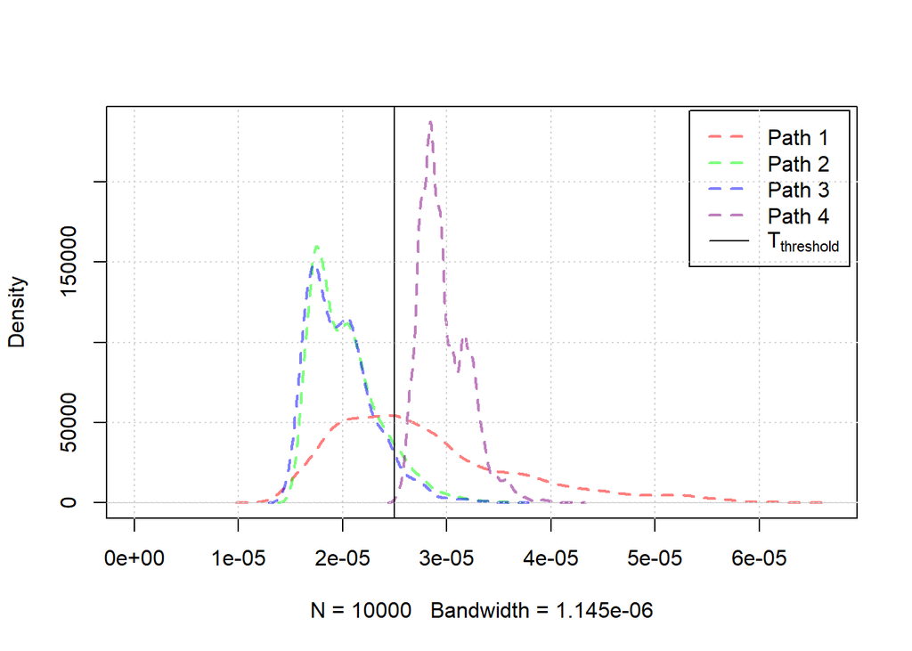

Percent above threshold for entire population:

```r
print(paste("Percentage above threshold theoretical:", theor_perc(mg1_packets_path1, threshold), "%"))
```

```
## [1] "Percentage above threshold theoretical: 55.13 %"
```

```r
print(paste("Percentage above threshold theoretical:", theor_perc(mg1_packets_path2, threshold), "%"))
```

```
## [1] "Percentage above threshold theoretical: 9.87 %"
```

```r
print(paste("Percentage above threshold theoretical:", theor_perc(mg1_packets_path3, threshold), "%"))
```

```
## [1] "Percentage above threshold theoretical: 6.92 %"
```

```r
print(paste("Percentage above threshold theoretical:", theor_perc(mg1_packets_path4, threshold), "%"))
```

```
## [1] "Percentage above threshold theoretical: 100 %"
```

```r
counts <- numeric(arms) # A vector initialized with zeros to track how many times each path has been selected
penalties <- numeric(arms) # A vector initialized with zeros to accumulate the total penalties (negative delays) obtained from each path

converged_at_trial <- 0
conv_num <- 25
convergence_threshold <- 1 #%
all_average_penalties <- list()
converged <- FALSE

for(i in 1:n_trials){
  # Decide to explore or exploit
  if(runif(1) < epsilon){
    # Exploration: choose a random path
    chosen_arm <- sample(arms, 1)
  } else {
    # Exploitation: choose the best path based on average penalty
    average_penalties <- penalties/pmax(counts, 1)
    chosen_arm <- which.max(average_penalties)
  }

  # Simulate the delay (penalty) from the chosen path
  delay <- switch(chosen_arm,
                 sample(mg1_packets_path1,1),
                 sample(mg1_packets_path2,1),
                 sample(mg1_packets_path3,1),
                 sample(mg1_packets_path4,1))

  # Update counts and penalties
  penalty = -ifelse(delay > threshold, 1, 0)
  counts[chosen_arm] <- counts[chosen_arm] + 1
  penalties[chosen_arm] <- penalties[chosen_arm] + penalty

  all_average_penalties[[i]] <- penalties/counts

  if (get_n_trial_convergence(all_average_penalties, i, conv_num, convergence_threshold)) {
    break
  }
}
```

```
## Error = 0.6301066 %
## Converged at trial 112
## Converged: TRUE
```

## Results

```r
average_rewards <- penalties/counts
cat("Counts of selections for each path:", counts, "\n")
```

```
## Counts of selections for each path: 23 12 51 26
```

```r
cat("Total rewards (negative delay) for each path:", penalties, "\n")
```

```
## Total rewards (negative delay) for each path: -12 -3 -2 -26
```

```r
cat("Average rewards (negative delay) for each path:", average_penalties, "\n")
```

```
## Average rewards (negative delay) for each path: -0.5263158 -0.3 -0.04255319 -1
```

```r
cat("Percent of packets above threshold simulated:", -average_penalties*1e2, "% \n")
```

```
## Percent of packets above threshold simulated: 52.63158 30 4.255319 100 %
```

```r
cat("Percent of packets above threshold theoretical:", theor_perc(mg1_packets_path1, threshold),theor_perc(mg1_packets_path2, threshold),theor_perc(mg1_packets_path3, threshold),theor_perc(mg1_packets_path4, threshold), "% \n")
```

```
## Percent of packets above threshold theoretical: 55.13 9.87 6.92 100 %
```

```r
cat("The best path is: Path", which.max(average_penalties), "\n")
```

```
## The best path is: Path 3
```